# Demonstration page of R Markdown with Health corporate theming

David Mortimer, HWD

5 July 2021

[figure not shown]

DRAFT

# 1 Executive Summary

R Markdown is a great way to turn your analysis into a portable, reproducible document - such as pdf or html. This document demonstrates how to incorporate Healths corporate style guide into Rmarkdown documents.

# 2 Purpose

This is basically just a demo of how to deal with a few issues with making R Markdown files comply with corporate styling - fonts, logo, heading sizes and colours, etc.

The features include:

- logo in the top right of the document, and modify the title’s width to allow for it
- heading styles and fonts in the html
- fonts and corporate colours used in the graphics
- document builds successfully even if the project is on a mapped network drive which usually causes problems with RStudio Server and Pandoc

# 3 Analysis

## 3.1 Data

The data presented are service volumes of the top 5 MBS items claimed by GP’s.

## 3.2 Findings

### 3.2.1 Raw data

We see a very strong seasonal pattern, as well as step changes associated with step change increases in COVID related telehealth items and associated reduction in item 23 volumes.

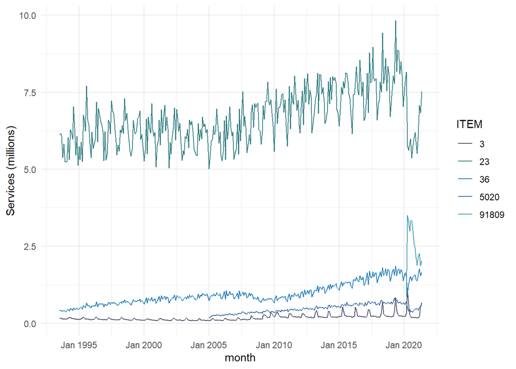

### 3.2.2 Seasonally adjusted - item 23 volumes

We can perform a seasonal adjustment to removed the monthly fluctuation around the trend.

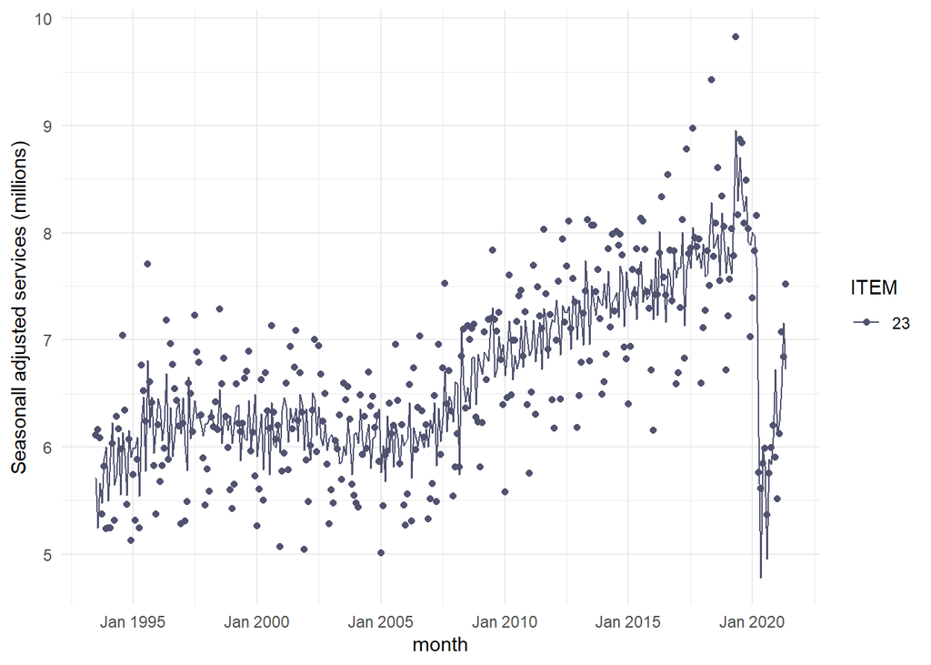